# 動物實驗設計與研究方法

Week 01｜Course Introduction and a Design Mindset

陳敬元 Jing-Yuan Chen, DVM, PhD

jychen@niar.org.tw

國家實驗研究院國家生物模式中心

宜蘭大學生物技術與動物科學系

September 10, 2026

# 第一節｜課程簡介 / Introduction

## 從共同目標與設計語言開始

1. 認識彼此的研究背景與學習需求
2. 課程所探討的核心問題
3. 討論幾個之後會反覆使用的語彙

## 獸醫師

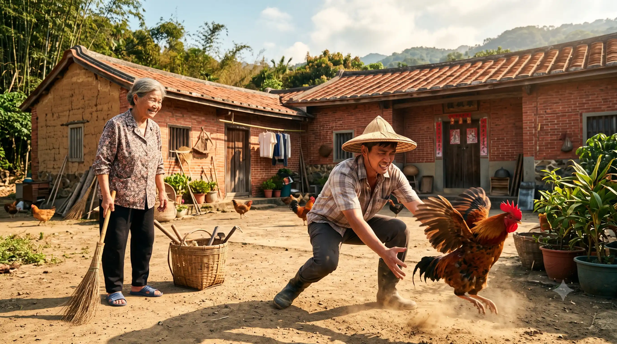

What my granny thinks I do

[figure not shown]

What I thought I would do

[figure not shown]

What my friends think I do

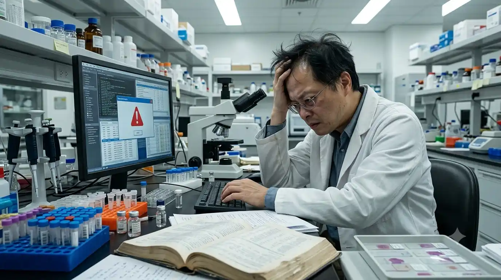

The real me

## 關於我｜About me

- 獸醫師 / 獸醫病理學
- 動物傳染病與疫苗研究
  - 豬病：CSFV, PCV2
  - 禽病：PaBV, AIV
- 非模式動物的單細胞轉錄體學 (single-cell transcriptomics)研究
  - 鸚鵡病毒接種模式
- 從動物設施與研究品質的角度  
  進行實驗設計

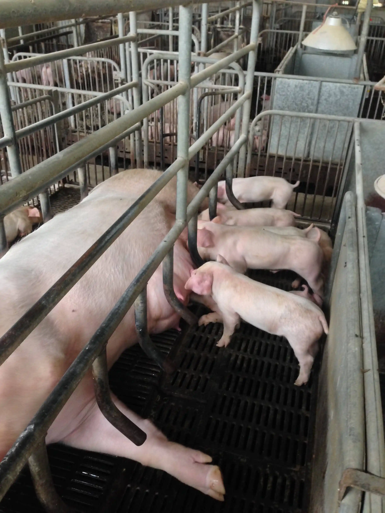

## 研究經驗一｜豬病與疫苗

- CSFV、PCV2、field trials
- 疫苗效力與田間應用
- 從田間問題到動物試驗

疫苗試驗要怎麼設計，  
才真的能回答田間牧場的問題？

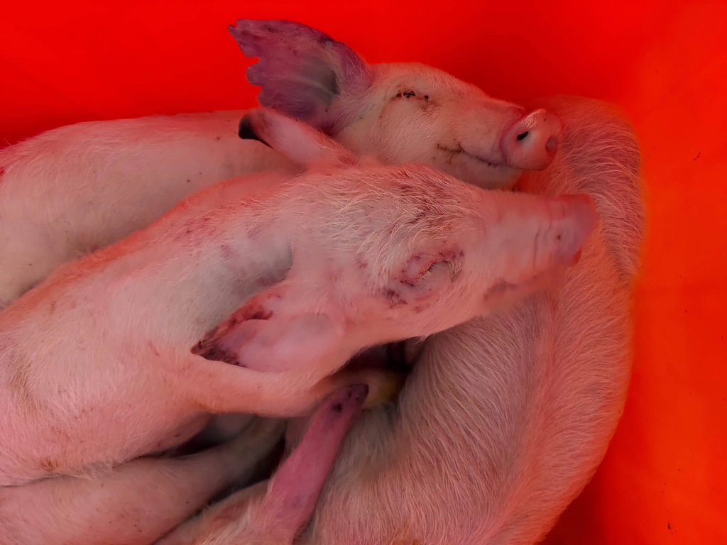

## 田間牧場實際的問題

- 疫苗反應

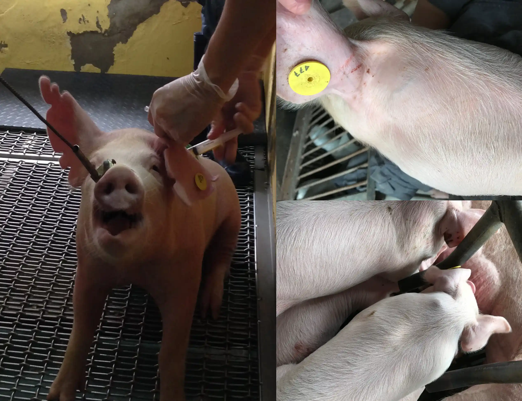

- 疾病發生、牧場環境、動物年齡

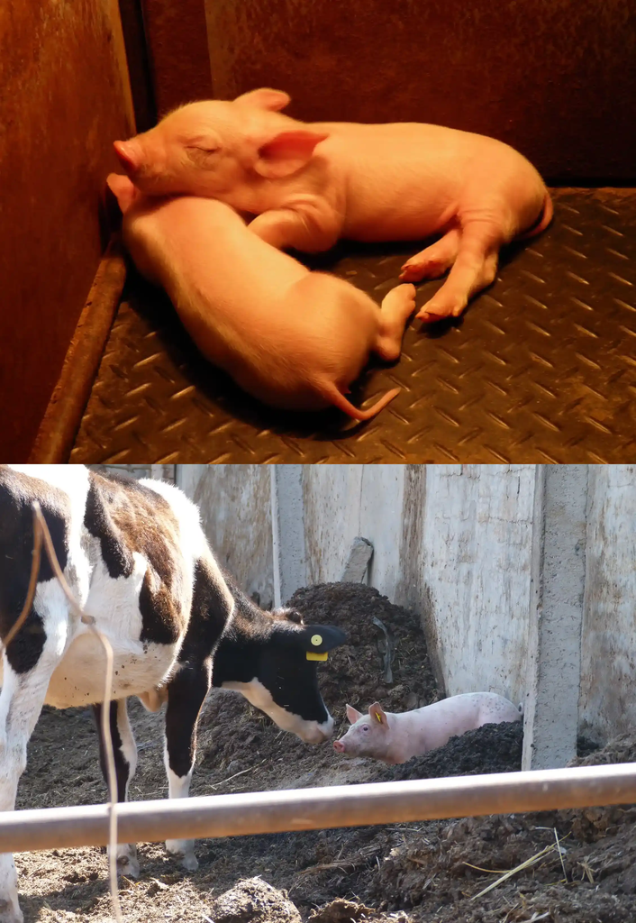

## 研究經驗二｜禽病與診斷

**病原檢測、病理變化與動物試驗**

- PaBV、AIV 與禽類疾病
- 疾病診斷、病理變化、監測
- 罕見 / 非模式動物試驗
  - PaBV inoculation on parrots

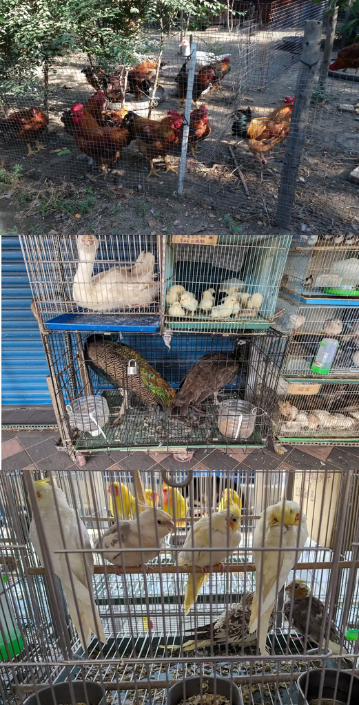

## 研究經驗三｜Host response 與 sequencing

- scRNA-seq、spatial approaches
- non-model species 與跨領域合作
- Nanopore、動物監測與研究品質
  - 罕見物種、非模式物種
  - 高維度探索、缺少參考資料

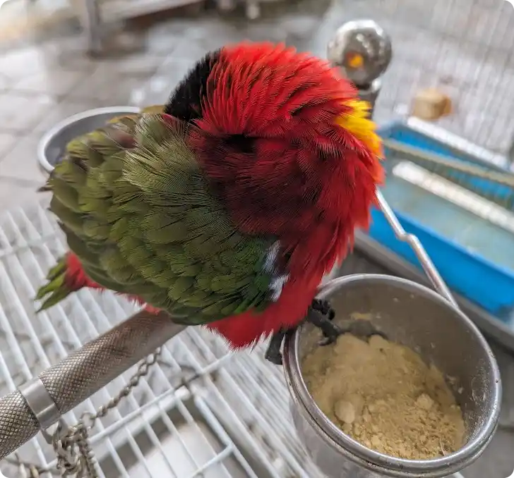

## 為什麼有這門課？

- 過往經驗
  - 要做動物實驗了！？
  - 找 paper、法規
  - 研究討論
  - 實際執行

[figure not shown]

- Paper 有類似的！
  - 拿來改一下
- 沒有人做過的實驗？
  - 新產品、非模式物種
  - 實驗計畫書 v 1, 2, 3,……
  - 實驗開始前大翻盤！！！

## 輪到你們｜Your turn

每人約 2 分鐘，請介紹：

1. 目前的年級、實驗室或研究方向 (stage and research area)
2. 過去經歷 (experience)
   - 是否接觸過動物實驗、研究計畫
   - paper reading 或 資料分析
3. 期待了解或學習的一件事 (What are you looking forward to?)

## 這門課怎麼進行

- 每週先透過課程講授與案例，建立一個 experimental design 的判斷角度
- 每位同學選擇一篇 original animal study，作為自己的 anchor paper
- 配合每週主題，逐步整理 research question、animal model、experimental unit、groups、outcomes、bias 與研究限制
- 累積的內容將形成個人案例摘要，以及期末 5 分鐘分享
- 專業術語保留英文，討論時以把研究內容說清楚為優先

## 一篇 paper，逐步讀完整

| 課程階段 | 閱讀重點 |
| --- | --- |
| **Weeks 1–4** | 選定 paper，釐清 animal use、animal model 與 research question |
| **Weeks 5–8** | 檢查 experimental unit、groups、outcomes 與 bias control |
| **Weeks 9–13** | 結合 PREPARE、ARRIVE，整理研究設計的優點與限制 |
| **Weeks 14–18** | 思考如何改進設計，完成案例摘要與 5 分鐘分享 |

> 每週增加一個閱讀角度，逐步累積，不需要反覆準備新的 paper report。

## 課程評量與學習任務

| 項目 | 比例 | 說明 |
| --- | --- | --- |
| 課堂參與與出席 | 40% | 穩定到課、完成課前準備並參與討論 |
| 課堂練習與案例討論 | 30% | 完成指定的課堂練習與案例判讀 |
| 個人簡短心得或案例摘要 | 20% | 逐步整理 anchor paper 的設計與限制 |
| 期末課堂分享或學習反思 | 10% | 以 5 分鐘分享整學期的案例整理與學習反思 |

# 第二節｜從一篇動物研究開始

## 讀一篇動物研究，先掌握四件事

1. 研究想回答什麼問題？
2. 研究使用哪些動物，如何安排比較？
3. 研究實際觀察到什麼結果？
4. 哪些限制會影響我們對結果的解讀？

接下來用一篇真實的 paper 練習這四個問題。

## 從一篇豬病的研究開始

### 牧場豬隻的跛行問題

- *Mycoplasma hyosynoviae* 可引起肥育豬關節炎 (arthritis) 與 跛行 (lameness)
- 跛行會影響動物福利，也可能增加抗生素使用
- 作者指出，目前尚無針對 *M. hyosynoviae* 的商用疫苗
- 自家疫苗 (autogenous vaccine) 的效果仍缺乏充分證據

**施打自家疫苗 (*M. hyosynoviae* bacterin)，是否能降低肥育期接受跛行治療的比例？**

**疫苗施打後的 IgG 抗體水準如何變化？**

Maaland & Oropeza-Moe. *Porcine Health Management*. 2026;12:26. https://doi.org/10.1186/s40813-026-00503-7

## Primary field trial｜主要試驗

- **Design**：randomized、blinded、saline-controlled field trial
- **Setting**：挪威一個肥育豬場及其來源仔豬場
- **Animals**：來自連續 3 個 batches 的豬隻
- **Allocation**：以個別豬隻分派 vaccine 或 saline control
- **Intervention**：6 與 9 週齡各肌肉注射 2 mL
- **Final analysis**：737 頭豬
  - vaccine：383
  - saline control：354
- **Primary endpoint**：肥育期間第一次因跛行接受 tiamulin 治療

## Exploratory serology｜研究設計

- 疫苗免疫與對照組豬隻的 *M. hyosynoviae*-specific IgG 抗體變化。

**批次豬隻**

| 項目 | 豬隻數 |
| --- | --- |
| 每個 batch | 免疫組 20＋對照組 20＝40 頭 |
| 3 個 batches | 原規劃 40 × 3＝120 頭 |
| 實際採樣 | 118 頭 |
| 選取方式 | 依現場條件採樣 (convenience sampling)；每欄選取 1–2 對 |

**縱向追蹤 (longitudinal sampling)**

| 週齡 | 採血時間點 |
| --- | --- |
| 6 週 | 第一次 vaccination 前 |
| 8 週 | 第一次 vaccination 後 |
| 13 週 | booster 後 |
| 19–21 週 | 肥育後期 |

- 檢測方式：T20 IgG ELISA

## Primary outcome｜跛行治療結果

- 免疫組：**7.8%**
- 對照組：**6.8%**
- 大多數案例發生在進入肥育場後前 3 週

**在這個牧場與研究條件下，疫苗未顯示可測得的跛行治療降低效果。**

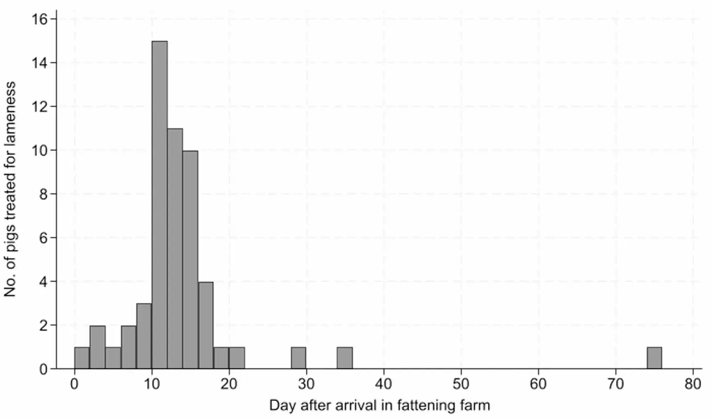

**Timing of first lameness treatment in 54 pigs.**

## Exploratory serology｜Antibody profile 隨時間變化

- 疫苗組別與 IgG seropositivity 無明顯關聯
- ELISA S/P value 隨 sampling time 變化
- 8 與 13 週齡較低、19–21 週齡最高
- **圖中兩組的 S/P value 分佈大致重疊**
- 本項探索性實驗未觀察到明確的組間差異

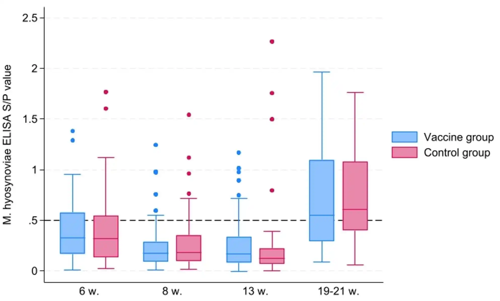

**T20 IgG ELISA antibody profiles.**

## 作者如何說明研究限制？

作者指出：

- 跛行動物缺少病原特異性的確診資訊。
- 其他可能影響的 bias:
  - Vaccination timing、early infection 與 maternal immunity 可能影響結果
- 血清學檢測只在部分動物進行，屬初步探索性的分析

從 study setting 還可以進一步追問：

- 單一牧場的結果，可以推廣到哪些場域與豬群？

## 回頭看：這篇 paper 包含哪些研究問題？

- **主要問題**：接種自家疫苗是否降低跛行治療的比率？
- **描述性結果**：血清抗體如何隨時間變化？
- **探索性分析**：血清抗體是否與豬隻發生跛行有關？

閱讀時先分清楚：哪一個是主要問題，哪些是補充觀察或 exploratory analysis。

## 把結果放回研究條件中解讀

### 這項研究實際觀察的是

- 單一牧場中的肥育豬
- 自家疫苗與對照組的比較
- 肥育期間因跛行而接受治療的比例

### 因此，研究結果支持的說法是

**在這個牧場與研究條件下，自家疫苗未顯示可測得的跛行治療降低效果。**

這個結果不等於已經證明該疫苗在所有牧場與所有條件下都無效。

## 選定你的 anchor paper

選擇一篇與自己研究方向相關的 original animal study。

下週先帶著 paper，記下：

1. 為什麼這項研究需要使用動物？
2. 作者選擇了什麼 animal model？
3. 你目前看到的一個 ethics 或 3Rs 問題是什麼？

下週會先以兩人一組，簡短交換這三項觀察；不需要準備完整報告。

## 本週案例與下週閱讀

**本週案例**

- Maaland & Oropeza-Moe (2026)  
  [Randomized controlled single-farm field evaluation](https://doi.org/10.1186/s40813-026-00503-7)

**下週先讀**

- NC3Rs  
  [The 3Rs](https://nc3rs.org.uk/who-we-are/3rs)

### 先理解 Replacement、Reduction 與 Refinement 的基本定義

## 後續課程會使用的資源

**設計與規劃**

- Smith *et al.* (2018)  
  [PREPARE: guidelines for planning animal research and testing](https://doi.org/10.1177/0023677217724823)

**報告與評讀**

- Percie du Sert *et al.* (2020)  
  [The ARRIVE guidelines 2.0](https://doi.org/10.1371/journal.pbio.3000410)

**設計工具**

- [NC3Rs Experimental Design Assistant](https://eda.nc3rs.org.uk/)  
  視覺化 experimental plan 與設計檢查工具

### 這些資源會在對應週次再正式使用